# BIO 221 Exam Predictions Consulting Report

## Introduction

```r
library(readr)
library(pander)
library(tidyverse)
library(DT)

# Get and Clean Data
scores <- read_csv("C:/Users/sarwi/Downloads/Statistics-Notebook-master/Statistics-Notebook-master/Data/BIO_221ExamScores.csv")
colnames(scores) <- c("Student", "RootAccount", "Section", "Exam1", "Exam2", "Exam3")

scores$Exam1 <- as.numeric(scores$Exam1)
scores$Exam2 <- as.numeric(scores$Exam2)
scores$Exam3 <- as.numeric(scores$Exam3)

scores <- scores %>%
  filter(Exam1 > 0, Exam2 > 0)

# numbies
scores$Avg12 <- (scores$Exam1 + scores$Exam2) / 2
scores$perImprovement <- ((scores$Exam2 - scores$Exam1) / scores$Exam1) * 100
```

For all models in this report, the p-values are extremely low (well below the standard 0.05 threshold), which confirms that the correlation between early and late assessments is statistically significant.

## Model 1a: Predicting Exam 2 from Exam 1

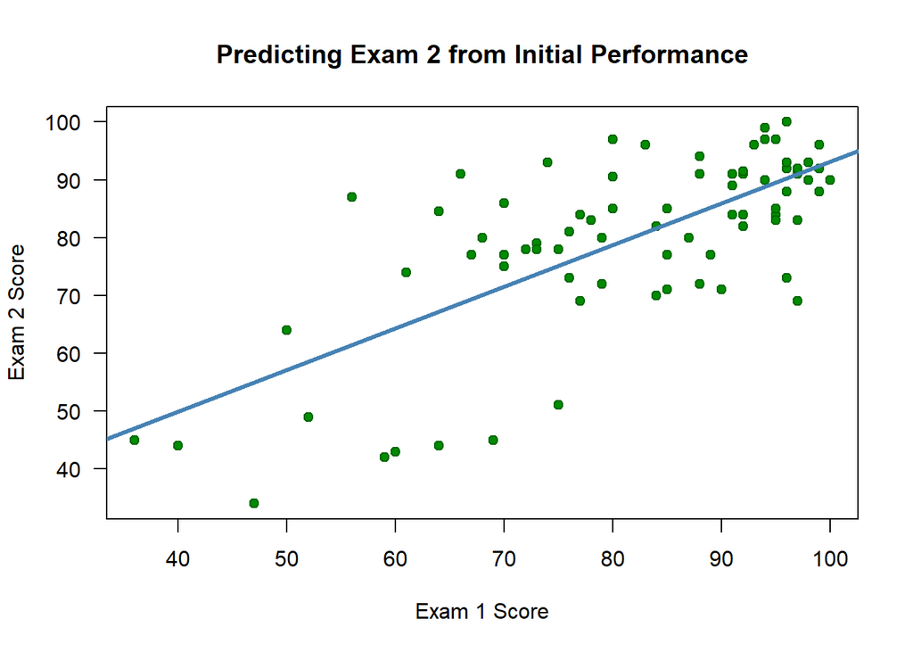

```r
# Predicting Exam 2 from Exam 1
model1 <- lm(Exam2 ~ Exam1, data = scores)

# Model1 Plot
plot(Exam2 ~ Exam1, data = scores, pch = 21, bg = "green4", col = "darkgreen", xlab = "Exam 1 Score", ylab = "Exam 2 Score", main = "Predicting Exam 2 from Initial Performance", las = 1)
abline(model1, col="steelblue", lwd=3)
```

Most students tend to stay in a similar scoring bracket for their second test, which suggests that without a major shift in how a student prepares, their results usually stay consistent early on.

```r
# Technical Summary
pander(summary(model1))
```

|  | Estimate | Std. Error | t value | Pr(>\|t\|) |
| --- | --- | --- | --- | --- |
| **(Intercept)** | 21.08 | 6.736 | 3.129 | 0.002479 |
| **Exam1** | 0.7204 | 0.08111 | 8.882 | 2.029e-13 |

Fitting linear model: Exam2 ~ Exam1

| Observations | Residual Std. Error | $R^2$ | Adjusted $R^2$ |
| --- | --- | --- | --- |
| 79 | 10.84 | 0.506 | 0.4996 |

## Model 1b: Predicting Exam 3 from Exam 2

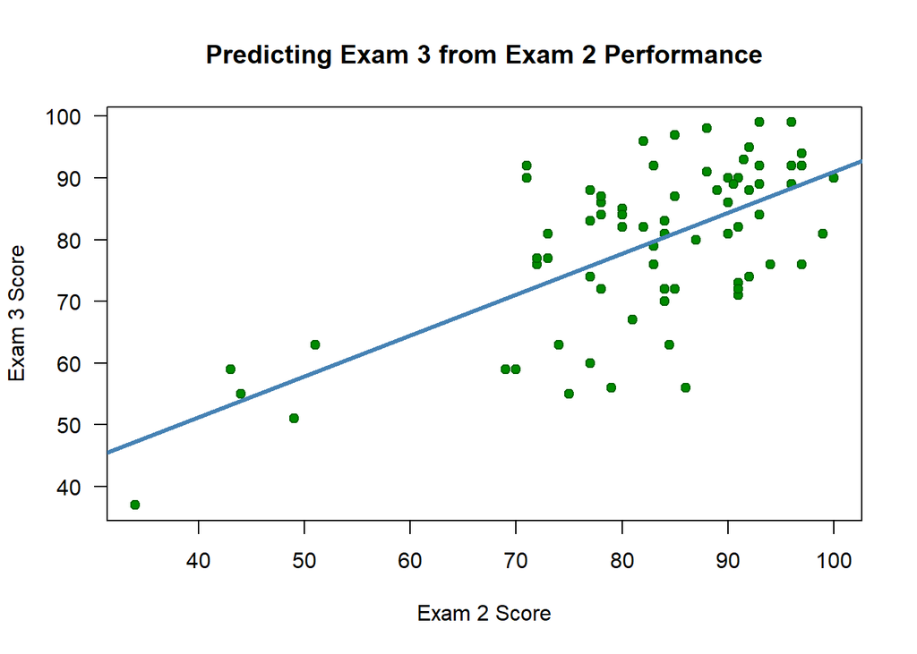

```r
# Predicting Exam 3 from Exam
e23_data <- scores %>% filter(!is.na(Exam3))
model1b <- lm(Exam3 ~ Exam2, data = e23_data)

# Model1b Plot
plot(Exam3 ~ Exam2, data = e23_data, pch = 21, bg = "green4", col = "darkgreen",
     xlab = "Exam 2 Score", ylab = "Exam 3 Score",
     main = "Predicting Exam 3 from Exam 2 Performance", las = 1)
abline(model1b, col="steelblue", lwd=3)
```

This model shows that Exam 3 performance is actually more closely tied to Exam 2 than it is to the very first test. If a student has successfully navigated the mid-semester jump in complexity, they have usually mastered the “rhythm” of the course, and a strong Exam 2 score is often the best green light for continued success on Exam 3.

```r
# Technical Summary
pander(summary(model1b))
```

|  | Estimate | Std. Error | t value | Pr(>\|t\|) |
| --- | --- | --- | --- | --- |
| **(Intercept)** | 24.76 | 7.533 | 3.287 | 0.001577 |
| **Exam2** | 0.6629 | 0.09046 | 7.328 | 2.923e-10 |

Fitting linear model: Exam3 ~ Exam2

| Observations | Residual Std. Error | $R^2$ | Adjusted $R^2$ |
| --- | --- | --- | --- |
| 73 | 10.06 | 0.4307 | 0.4226 |

## Model 2: Predicting Exam 3 From the Average Exam 1 and Exam 2 Scores

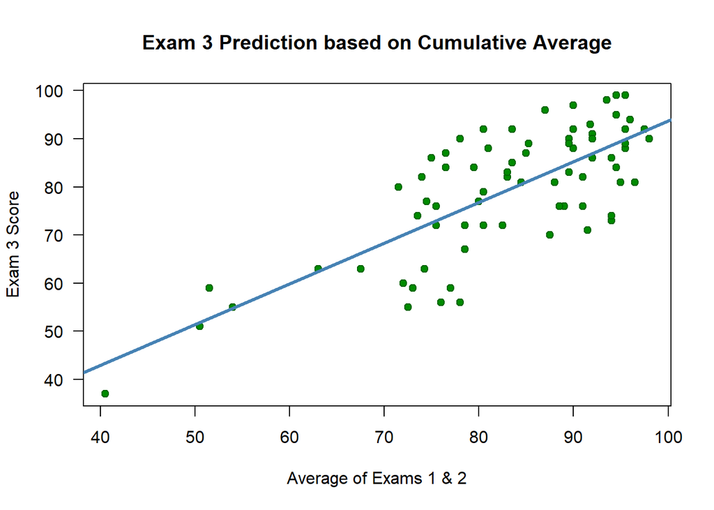

```r
# Predicting Exam 3 from Average of Exams 1 & 2
e3_data <- scores %>% filter(!is.na(Exam3))
model2 <- lm(Exam3 ~ Avg12, data = e3_data)

# Model 2 Plot
plot(Exam3 ~ Avg12, data = e3_data, pch = 21, bg =  "green4", col = "darkgreen",
     xlab = "Average of Exams 1 & 2", ylab = "Exam 3 Score",
     main = "Exam 3 Prediction based on Cumulative Average", las = 1)
abline(model2, col="steelblue", lwd=3)
```

To get a fairer view of a student’s standing heading into the third unit, this model uses the average of the first two exams to predict the third. This is the most reliable tool because using an average accounts for flukes. This data provides a more stable prediction for Exam 3, making it a tool for mid-semester advising before the third testing block.

```r
# Technical Summary
pander(summary(model2))
```

|  | Estimate | Std. Error | t value | Pr(>\|t\|) |
| --- | --- | --- | --- | --- |
| **(Intercept)** | 9.049 | 7.372 | 1.227 | 0.2237 |
| **Avg12** | 0.8471 | 0.08804 | 9.622 | 1.686e-14 |

Fitting linear model: Exam3 ~ Avg12

| Observations | Residual Std. Error | $R^2$ | Adjusted $R^2$ |
| --- | --- | --- | --- |
| 73 | 8.785 | 0.5659 | 0.5598 |

## Model 3: Predicting the Average Score of all Three Exams From Exam 1

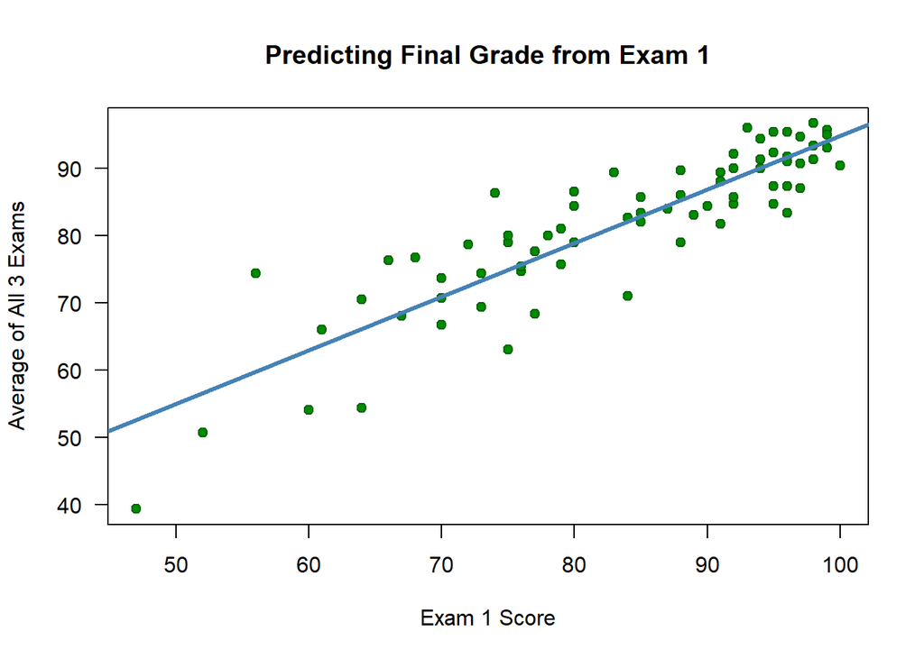

```r
# Predicting Total Exam Average from Exam 1 ---
#3-exam average
scores$AvgAll <- (scores$Exam1 + scores$Exam2 + scores$Exam3) / 3
e3_final <- scores %>% filter(!is.na(Exam3))
model3 <- lm(AvgAll ~ Exam1, data = e3_final)

# Model 3 Plot
plot(AvgAll ~ Exam1, data = e3_final, pch = 21, bg = "green4", col = "darkgreen",
     xlab = "Exam 1 Score", ylab = "Average of All 3 Exams",
     main = "Predicting Final Grade from Exam 1", las = 1)
abline(model3, col="steelblue", lwd=3)
```

```r
# Technical Summary
pander(summary(model3))
```

|  | Estimate | Std. Error | t value | Pr(>\|t\|) |
| --- | --- | --- | --- | --- |
| **(Intercept)** | 15.12 | 4.179 | 3.617 | 0.0005533 |
| **Exam1** | 0.7967 | 0.04943 | 16.12 | 2.008e-25 |

Fitting linear model: AvgAll ~ Exam1

| Observations | Residual Std. Error | $R^2$ | Adjusted $R^2$ |
| --- | --- | --- | --- |
| 73 | 5.381 | 0.7853 | 0.7823 |

## Interactive Tables

To use these interactive prediction tools, you simply locate a specific Exam 1 or Exam 2 score in the left-hand column by searching to see the statistically most likely outcomes in the following columns. To keep accuracy the predictions start at an exam score of 40%.

```r
# Range for Exam 1
range_e1 <- data.frame(Exam1 = seq(40, 100, by = 1))

# Predictions based on Exam 1
p_e2_from_e1 <- predict(model1, newdata = range_e1)
p_final_from_e1 <- predict(model3, newdata = range_e1)

table_phase1 <- data.frame(
  "Exam 1 Score" = range_e1$Exam1,
  "Predicted Exam 2" = round(p_e2_from_e1, 1),
  "Predicted Final Average" = round(p_final_from_e1, 1)
)

datatable(table_phase1,
          caption = "Table 1: Projections based on Exam 1 performance.",
          options = list(pageLength = 5, dom = 'ft'), rownames = FALSE)
```

| Exam.1.Score | Predicted.Exam.2 | Predicted.Final.Average |
| --- | --- | --- |
| 40 | 49.9 | 47 |
| 41 | 50.6 | 47.8 |
| 42 | 51.3 | 48.6 |
| 43 | 52.1 | 49.4 |
| 44 | 52.8 | 50.2 |
| 45 | 53.5 | 51 |
| 46 | 54.2 | 51.8 |
| 47 | 54.9 | 52.6 |
| 48 | 55.7 | 53.4 |
| 49 | 56.4 | 54.2 |

[output cut: 51 more lines]

```r
# Range for Exam 2
range_e2 <- data.frame(Exam2 = seq(40, 100, by = 1))

# Prediction for Exam 3 based ONLY on Exam 2 (Model 1b)
p_e3_from_e2 <- predict(model1b, newdata = range_e2)

table_phase2 <- data.frame(
  "Exam 2 Score" = range_e2$Exam2,
  "Predicted Exam 3" = round(p_e3_from_e2, 1)
)

datatable(table_phase2,
          caption = "Table 2: Projections based on actual Exam 2 performance.",
          options = list(pageLength = 5, dom = 'ft'),
          rownames = FALSE)
```

| Exam.2.Score | Predicted.Exam.3 |
| --- | --- |
| 40 | 51.3 |
| 41 | 51.9 |
| 42 | 52.6 |
| 43 | 53.3 |
| 44 | 53.9 |
| 45 | 54.6 |
| 46 | 55.3 |
| 47 | 55.9 |
| 48 | 56.6 |
| 49 | 57.2 |

[output cut: 51 more lines]

#### Disclaimer

These models are not meant to be a definitive limit on what a student can achieve, but rather a tool for informed decision-making.  
While the current models provide an effective degree of predictive accuracy for unit exams, there is a significant opportunity to expand these predictions by incorporating data from the comprehensive final exam.

## Mathematical Model and Hypothesis Testing

#### Mathematical Model

$$\hat{Y}_i = b_0 + b_1 X_i$$
$\hat{Y}_i$: The predicted score for a student. $b_0$: The y-intercept, representing the baseline score when the input variable is zero. $b_1$: The slope, which represents the predicted change in the average $Y$ score for every one-unit increase in the $X$ score.

#### Slope Hypothesis Testing

$$H_0: \beta_1 = 0$$
$$H_a: \beta_1 \neq 0$$
The null hypothesis ($H_0$) assumes there is no relationship between the exams. However, because our p-values were significantly low, we rejected the null hypothesis in every case, confirming that early performance is a statistically valid predictor of future results.

## Assumptions Check Appendix

#### Model 1a

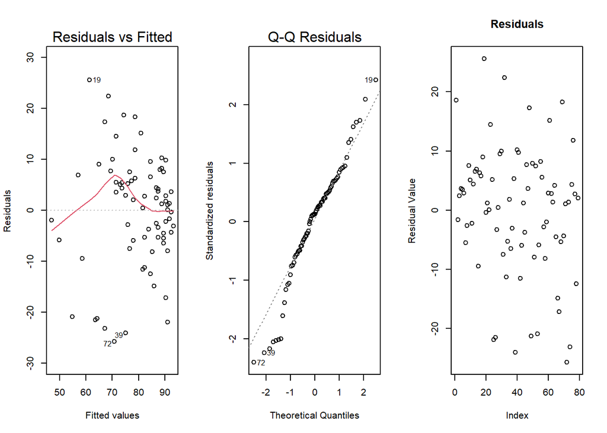

```r
# Diagnostics
par(mfrow=c(1,3))
plot(model1, which=1:2)
plot(model1$residuals, main="Residuals", ylab="Residual Value")
```

#### Model 1b

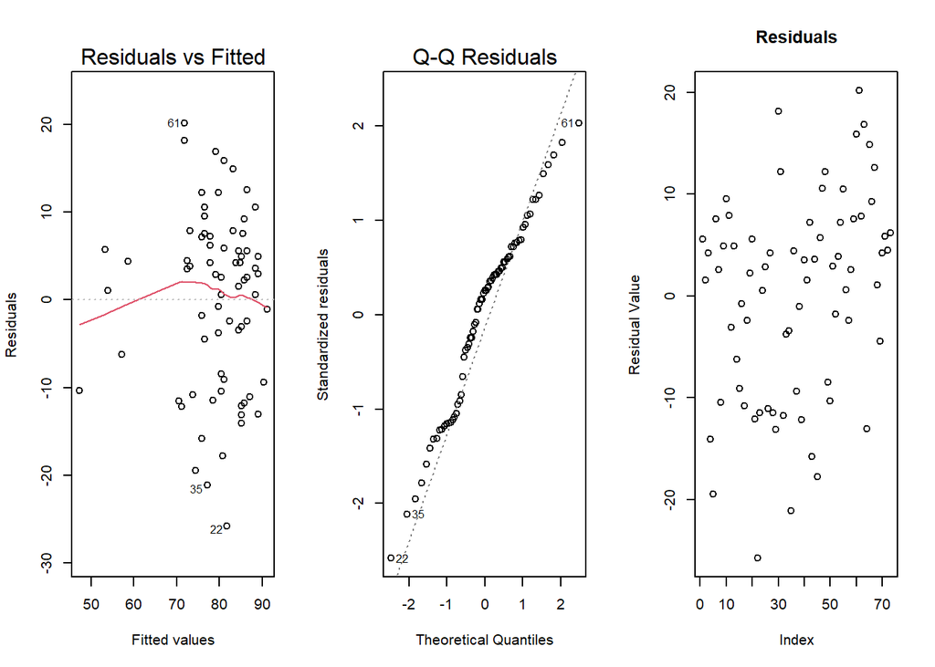

```r
par(mfrow=c(1,3))
plot(model1b, which=1:2)
plot(model1b$residuals, main="Residuals", ylab="Residual Value")
```

#### Model 2

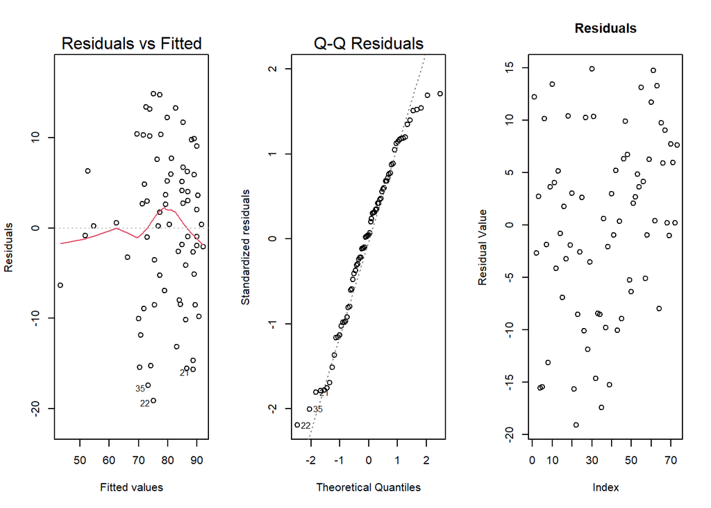

```r
# Diagnostics
par(mfrow=c(1,3))
plot(model2, which=1:2)
plot(model2$residuals, main="Residuals", ylab="Residual Value")
```

#### Model 3

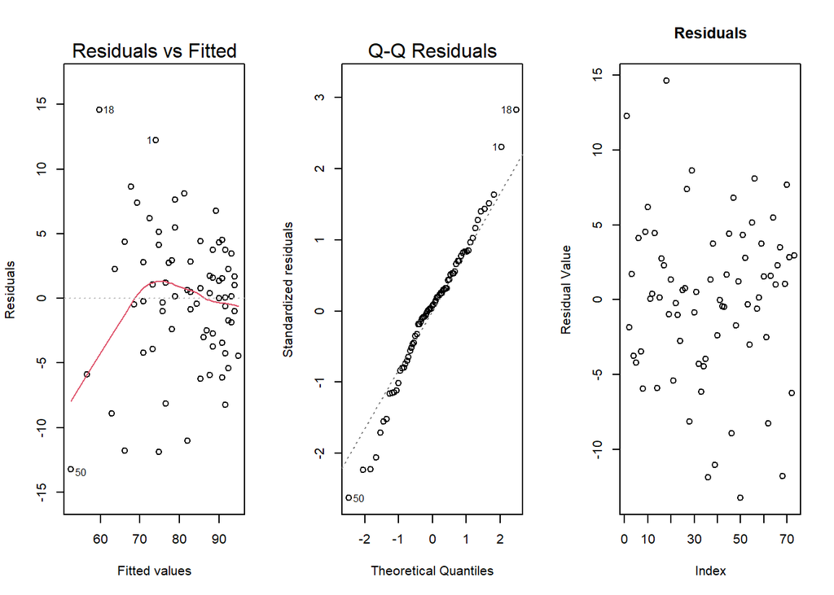

```r
# Diagnostics
par(mfrow=c(1,3))
plot(model3, which=1:2)
plot(model3$residuals, main="Residuals", ylab="Residual Value")
```

#### Acknowledgments

I would like to acknowledge my bother for his help in creating the interactive datatables.